# PML Project 1

claudio freitas

Tuesday, June 09, 2015

## Final Project Practical Machine Learning

Below is the final project for the Practical Machine Learning course. The project was developed in a Windows 7 platformwith R studio Version 0.98.1087.

## Executive Summary

The project uses data collected with devices such as Jawbone Up, Nike FuelBand, and Fitbit. According to the project background written in the course´s website the “goal will be to use data from accelerometers on the belt, forearm, arm, and dumbell of 6 participants. They were asked to perform barbell lifts correctly and incorrectly in 5 different ways”. The goal of the project is try to quantify how well the exercise is done with the variable “Classe”.

## Data Source

The training data for this project are available here:

https://d396qusza40orc.cloudfront.net/predmachlearn/pml-training.csv

The test data are available here:

https://d396qusza40orc.cloudfront.net/predmachlearn/pml-testing.csv

## Data Collection and reproducibility

Collecting data and ensuring reproducibility.

```r
library(caret)
library(rattle)
```

```r
library(rpart)
library(rpart.plot)
library(randomForest)
set.seed(2133459)

trainurl <- "http://d396qusza40orc.cloudfront.net/predmachlearn/pml-training.csv"
testurl <- "http://d396qusza40orc.cloudfront.net/predmachlearn/pml-testing.csv"
train <- read.csv(trainurl, na.strings=c("NA", "#DIV/0!","" ))
test <- read.csv(testurl, na.strings=c("NA", "#DIV/0!","" ))
str(train)
```

```
## 'data.frame':    19622 obs. of  160 variables:
##  $ X                       : int  1 2 3 4 5 6 7 8 9 10 ...
##  $ user_name               : Factor w/ 6 levels "adelmo","carlitos",..: 2 2 2 2 2 2 2 2 2 2 ...
##  $ raw_timestamp_part_1    : int  1323084231 1323084231 1323084231 1323084232 1323084232 1323084232 1323084232 1323084232 1323084232 1323084232 ...
##  $ raw_timestamp_part_2    : int  788290 808298 820366 120339 196328 304277 368296 440390 484323 484434 ...
##  $ cvtd_timestamp          : Factor w/ 20 levels "02/12/2011 13:32",..: 9 9 9 9 9 9 9 9 9 9 ...
##  $ new_window              : Factor w/ 2 levels "no","yes": 1 1 1 1 1 1 1 1 1 1 ...
##  $ num_window              : int  11 11 11 12 12 12 12 12 12 12 ...
##  $ roll_belt               : num  1.41 1.41 1.42 1.48 1.48 1.45 1.42 1.42 1.43 1.45 ...
##  $ pitch_belt              : num  8.07 8.07 8.07 8.05 8.07 8.06 8.09 8.13 8.16 8.17 ...
##  $ yaw_belt                : num  -94.4 -94.4 -94.4 -94.4 -94.4 -94.4 -94.4 -94.4 -94.4 -94.4 ...
##  $ total_accel_belt        : int  3 3 3 3 3 3 3 3 3 3 ...
##  $ kurtosis_roll_belt      : num  NA NA NA NA NA NA NA NA NA NA ...
##  $ kurtosis_picth_belt     : num  NA NA NA NA NA NA NA NA NA NA ...
##  $ kurtosis_yaw_belt       : logi  NA NA NA NA NA NA ...
```

[output cut: 86 more lines]

## Cleaning Variables

First we have to exclude the first 7 colunms that will not be helpful in the model.

```r
train <- train[,-c(1:7)]
test <- test[,-c(1:7)]
dim(train)
```

```
## [1] 19622   153
```

From the above data it is clear that there are many variables with NAs that should be extracted from the test data. But first we have to deal with near zero values that have no meaning in the prediction, we will use the nearZeroVar function:

```r
nzvtrain <- nearZeroVar(train, saveMetrics=T)
newtrain <- train[, nzvtrain$nzv==F]
nzvtest <- nearZeroVar(test, saveMetrics=T)
newtest <- test[, nzvtest$nzv==F]
```

Now it is important to extract the columns that are all NAs.

```r
naindex<- sapply(newtrain, function(x){sum(is.na(x))})
newtrain<- newtrain[ ,naindex==F]
naindex<- sapply(newtest, function(x){sum(is.na(x))})
newtest<- newtest[ ,naindex==F]
str(newtrain)
```

```
## 'data.frame':    19622 obs. of  53 variables:
##  $ roll_belt           : num  1.41 1.41 1.42 1.48 1.48 1.45 1.42 1.42 1.43 1.45 ...
##  $ pitch_belt          : num  8.07 8.07 8.07 8.05 8.07 8.06 8.09 8.13 8.16 8.17 ...
##  $ yaw_belt            : num  -94.4 -94.4 -94.4 -94.4 -94.4 -94.4 -94.4 -94.4 -94.4 -94.4 ...
##  $ total_accel_belt    : int  3 3 3 3 3 3 3 3 3 3 ...
##  $ gyros_belt_x        : num  0 0.02 0 0.02 0.02 0.02 0.02 0.02 0.02 0.03 ...
##  $ gyros_belt_y        : num  0 0 0 0 0.02 0 0 0 0 0 ...
##  $ gyros_belt_z        : num  -0.02 -0.02 -0.02 -0.03 -0.02 -0.02 -0.02 -0.02 -0.02 0 ...
##  $ accel_belt_x        : int  -21 -22 -20 -22 -21 -21 -22 -22 -20 -21 ...
##  $ accel_belt_y        : int  4 4 5 3 2 4 3 4 2 4 ...
##  $ accel_belt_z        : int  22 22 23 21 24 21 21 21 24 22 ...
##  $ magnet_belt_x       : int  -3 -7 -2 -6 -6 0 -4 -2 1 -3 ...
##  $ magnet_belt_y       : int  599 608 600 604 600 603 599 603 602 609 ...
##  $ magnet_belt_z       : int  -313 -311 -305 -310 -302 -312 -311 -313 -312 -308 ...
##  $ roll_arm            : num  -128 -128 -128 -128 -128 -128 -128 -128 -128 -128 ...
```

[output cut: 39 more lines]

```r
#dim(newtest)
```

```r
newtrain2 <- createDataPartition(y=newtrain$classe, p=0.7, list = F)
newtrain <- newtrain[newtrain2, ]
newvalidation <- newtrain[-newtrain2, ]
```

## Decision Tree Model

Creating a Decision Tree model:

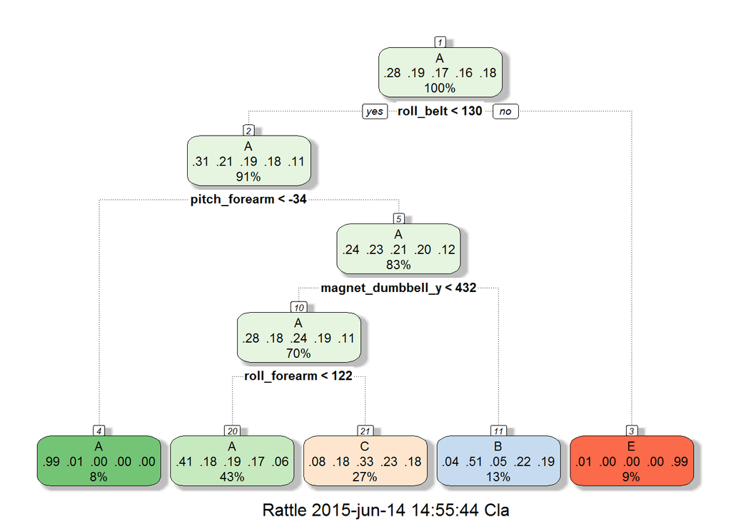

```r
modeltree<- train(classe ~., method="rpart", data=newtrain)
fancyRpartPlot(modeltree$finalModel)
```

## Testing the Decision Tree model in the Training set and in the Cross Validation set

Now we use the ConfusionMatrix function to analyse the model with the train set:

```r
prediction1 <- predict(modeltree, newdata = newtrain)
confusionMatrix(prediction1, newtrain$classe)
```

```
## Confusion Matrix and Statistics
##
##           Reference
## Prediction    A    B    C    D    E
##          A 3547 1071 1113  997  349
##          B   74  937   84  402  342
##          C  274  650 1199  853  675
##          D    0    0    0    0    0
##          E   11    0    0    0 1159
##
## Overall Statistics
##
##                Accuracy : 0.4981
##                  95% CI : (0.4897, 0.5065)
##     No Information Rate : 0.2843
##     P-Value [Acc > NIR] : < 2.2e-16
##
##                   Kappa : 0.3444
##  Mcnemar's Test P-Value : NA
##
## Statistics by Class:
##
##                      Class: A Class: B Class: C Class: D Class: E
## Sensitivity            0.9081  0.35252  0.50042   0.0000  0.45901
## Specificity            0.6409  0.91858  0.78379   1.0000  0.99902
## Pos Pred Value         0.5012  0.50952  0.32840      NaN  0.99060
## Neg Pred Value         0.9461  0.85535  0.88132   0.8361  0.89130
## Prevalence             0.2843  0.19349  0.17442   0.1639  0.18381
## Detection Rate         0.2582  0.06821  0.08728   0.0000  0.08437
## Detection Prevalence   0.5152  0.13387  0.26578   0.0000  0.08517
## Balanced Accuracy      0.7745  0.63555  0.64211   0.5000  0.72901
```

And the valitation set

```r
prediction2 <- predict(modeltree, newvalidation)
confusionMatrix(prediction2, newvalidation$classe)
```

```
## Confusion Matrix and Statistics
##
##           Reference
## Prediction    A    B    C    D    E
##          A 1060  313  313  292   94
##          B   18  304   17  112  107
##          C   87  191  379  274  213
##          D    0    0    0    0    0
##          E    4    0    0    0  341
##
## Overall Statistics
##
##                Accuracy : 0.5059
##                  95% CI : (0.4906, 0.5213)
##     No Information Rate : 0.2838
##     P-Value [Acc > NIR] : < 2.2e-16
##
##                   Kappa : 0.3563
##  Mcnemar's Test P-Value : NA
##
## Statistics by Class:
##
##                      Class: A Class: B Class: C Class: D Class: E
## Sensitivity            0.9068   0.3762  0.53456   0.0000  0.45166
## Specificity            0.6569   0.9233  0.77566   1.0000  0.99881
## Pos Pred Value         0.5116   0.5448  0.33129      NaN  0.98841
## Neg Pred Value         0.9468   0.8585  0.88908   0.8354  0.89030
## Prevalence             0.2838   0.1962  0.17213   0.1646  0.18330
## Detection Rate         0.2573   0.0738  0.09201   0.0000  0.08279
## Detection Prevalence   0.5030   0.1355  0.27774   0.0000  0.08376
## Balanced Accuracy      0.7819   0.6498  0.65511   0.5000  0.72523
```

## Randon Forest Model

We will now create a randon forest model to predict classe agaisnt all other variables

```r
modelrf<- randomForest(classe ~., data=newtrain)
```

## Testing the model in the Training set and in the Cross Validation set

Now we use the ConfusionMatrix function to analyse the model with the train set:

```r
prediction1 <- predict(modelrf, newdata = newtrain)
confusionMatrix(prediction1, newtrain$classe)
```

```
## Confusion Matrix and Statistics
##
##           Reference
## Prediction    A    B    C    D    E
##          A 3906    0    0    0    0
##          B    0 2658    0    0    0
##          C    0    0 2396    0    0
##          D    0    0    0 2252    0
##          E    0    0    0    0 2525
##
## Overall Statistics
##
##                Accuracy : 1
##                  95% CI : (0.9997, 1)
##     No Information Rate : 0.2843
##     P-Value [Acc > NIR] : < 2.2e-16
##
##                   Kappa : 1
##  Mcnemar's Test P-Value : NA
##
## Statistics by Class:
##
##                      Class: A Class: B Class: C Class: D Class: E
## Sensitivity            1.0000   1.0000   1.0000   1.0000   1.0000
## Specificity            1.0000   1.0000   1.0000   1.0000   1.0000
## Pos Pred Value         1.0000   1.0000   1.0000   1.0000   1.0000
## Neg Pred Value         1.0000   1.0000   1.0000   1.0000   1.0000
## Prevalence             0.2843   0.1935   0.1744   0.1639   0.1838
## Detection Rate         0.2843   0.1935   0.1744   0.1639   0.1838
## Detection Prevalence   0.2843   0.1935   0.1744   0.1639   0.1838
## Balanced Accuracy      1.0000   1.0000   1.0000   1.0000   1.0000
```

And the valitation set

```r
prediction2 <- predict(modelrf, newvalidation)
confusionMatrix(prediction2, newvalidation$classe)
```

```
## Confusion Matrix and Statistics
##
##           Reference
## Prediction    A    B    C    D    E
##          A 1169    0    0    0    0
##          B    0  808    0    0    0
##          C    0    0  709    0    0
##          D    0    0    0  678    0
##          E    0    0    0    0  755
##
## Overall Statistics
##
##                Accuracy : 1
##                  95% CI : (0.9991, 1)
##     No Information Rate : 0.2838
##     P-Value [Acc > NIR] : < 2.2e-16
##
##                   Kappa : 1
##  Mcnemar's Test P-Value : NA
##
## Statistics by Class:
##
##                      Class: A Class: B Class: C Class: D Class: E
## Sensitivity            1.0000   1.0000   1.0000   1.0000   1.0000
## Specificity            1.0000   1.0000   1.0000   1.0000   1.0000
## Pos Pred Value         1.0000   1.0000   1.0000   1.0000   1.0000
## Neg Pred Value         1.0000   1.0000   1.0000   1.0000   1.0000
## Prevalence             0.2838   0.1962   0.1721   0.1646   0.1833
## Detection Rate         0.2838   0.1962   0.1721   0.1646   0.1833
## Detection Prevalence   0.2838   0.1962   0.1721   0.1646   0.1833
## Balanced Accuracy      1.0000   1.0000   1.0000   1.0000   1.0000
```

## Generating Answers

we will use the Randon Forest model which had better results according to the confusionMatrix function.

```r
newnewtrain<- newtrain
newnewtrain$classe<- NULL
remove<- colnames(newnewtrain)
newtest<- test[remove]
#newtest<- cbind(newtest, test$problem_id)
prediction3 <- predict(modelrf, newtest)
prediction3
```

```
##  1  2  3  4  5  6  7  8  9 10 11 12 13 14 15 16 17 18 19 20
##  B  A  B  A  A  E  D  B  A  A  B  C  B  A  E  E  A  B  B  B
## Levels: A B C D E
```

```r
#prediction3<-cbind(as.character(prediction3), test$problem_id)
n<-20
pml_write_files = function(x){
  for(i in 1:n){
    filename = paste0("problem_id_",i,".txt")
   write.table(x[i],file=filename,quote=FALSE,row.names=FALSE,col.names=FALSE)
  }
}

pml_write_files(prediction3)
#prediction3
```